# H08 Stage 2: implementation, diagnostics, and V0 comparison

Visual light sensitivity and personal light exposure — author result gate

Published

August 12, 2026

**NoteAccepted Stage 2 package with bounded METRIC-011 maintenance**

The author accepted this Stage 2 result package before the Stage 3 and Stage 4 reports were created. On 2026-08-12, shared decision METRIC-011 normalised eight L10 participant-day round-off remnants to exact numerical zero. The bounded H08 reseal refitted only the inherited primary-dataset L10 branches and their specified diagnostics and sensitivities, then recalculated the four affected nine-member BH families. It did not rerun the full analysis or any resampling. The retained results, displayed values, diagnostic dispositions, sensitivity classifications, and scientific claims remained unchanged.

# 1 Hypothesis and analytical question

The signed preregistration states:

> **H8: Duration-, exposure-history-, and level-based metrics are associated with VLSQ-8 light sensitivity scores.**

The audited question is whether participant-level VLSQ-8 scores are associated with repeated participant-day personal light-exposure metrics after adjustment for submitted site. Near-eye measurements are primary; chest measurements are complementary. Temperature and other unsupported predictors are absent.

The predefined preparation sensitivity is called the **gap-timing-unaware dataset**. It still passed the general 50%-per-hour and 80%-per-day coverage rules. The name means that the timing of the remaining missing observations is not used for an additional metric-specific adjustment; it does not mean that gaps, missingness, or coverage were ignored. For this one-time first explanation, the primary could be interpreted as a time-sensitive primary metric dataset because its approved preparation uses the timing of remaining missing observations where that timing is relevant. From here onward, it is called simply the **primary dataset**.

# 2 Frozen implementation contract

All 14 Stage 1 decisions are recorded as approved, and all 20 sealed inputs match their pinned SHA-256 values.

Implementation preconditions

| Check | Result |
| --- | --- |
| Approved H08-G decisions | 14 / 14 |
| Pinned input hashes verified | 20 / 20 |

The accepted analysis and the bounded METRIC-011 reseal stop immediately if an approval, input pin, or invariance check fails.

## 2.1 METRIC-011 exact-zero reseal

The controlling METRIC-011 decision classifies floating-point remnants that are numerically zero as exact zero. Its independently verified evidence identified eight affected primary L10 means: three near-eye and five chest participant-days changed from `4.163336342344337e-17` lx to `0` lx. All samples, non-L10 values, hourly and 30-minute values, gap-timing-unaware values, V0 outputs, and the accepted exactly identified longest-period and observed-dose sensitivities were protected.

Table 1

Bounded METRIC-011 reseal

| Check | Observed | Interpretation |
| --- | --- | --- |
| Primary L10 source cells | 8: 3 near eye; 5 chest | Exact-zero normalisation only; no sample changed |
| Primary-dataset L10 model bundles | 6 | All-available, paired-placement, and preparation-common samples for both placements |
| Inherited L10 sensitivity bundles | 4 | Photoperiod and participant-summary fits for both placements |
| L10 leave-one-site-out refits | 17 | All completed; influence interpretation unchanged |
| Affected BH-family rows | 36 across 4 families | 3 adjusted values differed below display precision; no displayed p-value or decision changed |
| Reader-display checks | 6 / 6 PASS | Effects, p-values, diagnostics, and sensitivity summaries retained their accepted display |
| Protected-scope reconciliation | 33 / 33 PASS | Every untargeted row, field, model object, and protected artifact matched its accepted identity |

The three sub-display adjusted-p differences comprise two L10 values and one M10 family derivative. None changed a three-decimal display or BH-adjusted conclusion.

The result comparison, complete-family BH record, display-invariance record, and 33-scope reconciliation provide the machine-readable audit trail. Because no retained result or claim changed, the existing author approval remains applicable.

## 2.2 VLSQ-8 scoring and scaling

The participant-level predictor is complete for all 184 participants across nine sites. The stored score equals the sum of the eight ordered 1–5 item codes plus 5 for every participant. Its observed range is 13–39, its mean is 21.597826, and its participant standard deviation is 5.539840. Models use the centred raw score; practical effects compare scores separated by one such standard deviation. No within-site standardisation was applied.

VLSQ-8 score audit

| Participants | Sites | Missing scores | Missing item cells | Range | Mean | SD | Stored − item sum | Verified |
| --- | --- | --- | --- | --- | --- | --- | --- | --- |
| 184 | 9 | 0 | 0 | 13–39 | 21.597826 | 5.539840 | 5 | TRUE |

The +5 scoring constant is an author-approved project convention; it is not claimed as a published standard total-score algorithm.

## 2.3 Exact fitted formulas

The following evaluated cell is the complete formula contract. Site uses the submitted order and explicit sum contrasts. `site:Id` is the participant random-intercept grouping factor; participants remain nested within site.

```r
site_only <- stats::as.formula(
  "response_value ~ site + (1 | site:Id)"
)
additive <- stats::as.formula(
  "response_value ~ site + VLSQ8_c + (1 | site:Id)"
)
interaction <- stats::as.formula(
  "response_value ~ site * VLSQ8_c + (1 | site:Id)"
)
photoperiod_site_only <- stats::as.formula(
  "response_value ~ site + photoperiod_c + (1 | site:Id)"
)
photoperiod_additive <- stats::as.formula(
  "response_value ~ site + photoperiod_c + VLSQ8_c + (1 | site:Id)"
)
photoperiod_interaction <- stats::as.formula(
  "response_value ~ site * VLSQ8_c + photoperiod_c + (1 | site:Id)"
)
participant_site_only <- stats::as.formula(
  "participant_response ~ site"
)
participant_additive <- stats::as.formula(
  "participant_response ~ site + VLSQ8_c"
)
participant_interaction <- stats::as.formula(
  "participant_response ~ site * VLSQ8_c"
)

site_only
```

```
response_value ~ site + (1 | site:Id)
```

```r
additive
```

```
response_value ~ site + VLSQ8_c + (1 | site:Id)
```

```r
interaction
```

```
response_value ~ site * VLSQ8_c + (1 | site:Id)
```

```r
photoperiod_site_only
```

```
response_value ~ site + photoperiod_c + (1 | site:Id)
```

```r
photoperiod_additive
```

```
response_value ~ site + photoperiod_c + VLSQ8_c + (1 | site:Id)
```

```r
photoperiod_interaction
```

```
response_value ~ site * VLSQ8_c + photoperiod_c + (1 | site:Id)
```

```r
participant_site_only
```

```
participant_response ~ site
```

```r
participant_additive
```

```
participant_response ~ site + VLSQ8_c
```

```r
participant_interaction
```

```
participant_response ~ site * VLSQ8_c
```

The primary average association is the likelihood-ratio comparison of `site_only` with `additive`. Site heterogeneity is the separate comparison of `additive` with `interaction`. These tests answer different questions and are adjusted in different complete nine-member Benjamini–Hochberg families.

## 2.4 Metrics, response families, and practical estimands

Nine-member H08 response contract

| Order | Metric | Category | Unit | Response / transform | Effect shown | Participant-day value |
| --- | --- | --- | --- | --- | --- | --- |
| 1 | Mean melEDI | level-based | lx | gaussian / log10_offset_0.1 | Ratio per VLSQ-8 SD | Supported hybrid-day geometric mean; no coverage scaling |
| 2 | Brightest 10 h mean | level-based | lx | gaussian / log10_offset_0.1 | Ratio per VLSQ-8 SD | Brightest supported 10 h geometric mean |
| 3 | Darkest 10 h mean | level-based | lx | gaussian / log10_offset_0.1 | Ratio per VLSQ-8 SD | Darkest supported midnight-wrapping 10 h geometric mean |
| 4 | Time above 1,000 lx melEDI | duration-based | h | tweedie_log / identity | Ratio per VLSQ-8 SD | Actual supported time above 1,000 lx melEDI |
| 5 | Time above 250 lx melEDI during wake | duration-based | h | tweedie_log / identity | Ratio per VLSQ-8 SD | Actual supported waking near-eye/chest time above 250 lx melEDI |
| 6 | Time below 10 lx melEDI before sleep | duration-based | h | gaussian / identity | Hour difference per VLSQ-8 SD | Calendar-day cumulative supported pre-sleep time below 10 lx melEDI |
| 7 | Time below 1 lx melEDI during sleep | duration-based | h | tweedie_log / identity | Ratio per VLSQ-8 SD | Supported bedside sleep-environment time below 1 lx melEDI |
| 8 | Longest continuous period above 250 lx melEDI | duration-based | h | gaussian / log10_offset_0.1 | Ratio per VLSQ-8 SD | Observed lower bound for the longest continuous period above 250 lx melEDI |
| 9 | melEDI dose | exposure-history-based | lx·h | gaussian / log10_offset_0.1 | Ratio per VLSQ-8 SD | Time-sensitive corrected melEDI dose |

melEDI and manuscript-facing period terminology are used throughout.

# 3 Exact fitted samples

Every row entering each model was fixed before fitting. The compact tables below report participants / participant-days / sites. Row-key and full model-frame SHA-256 values are preserved in the source artifact.

## 3.1 All available samples by dataset and placement

Exact all-available fitted samples

| Metric | Gap-timing-unaware dataset_Chest | Gap-timing-unaware dataset_Near eye | Primary dataset_Chest | Primary dataset_Near eye |
| --- | --- | --- | --- | --- |
| Mean melEDI | 154 / 897 / 8 | 141 / 811 / 9 | 154 / 902 / 8 | 141 / 816 / 9 |
| Brightest 10 h mean | 154 / 897 / 8 | 141 / 811 / 9 | 154 / 902 / 8 | 141 / 816 / 9 |
| Darkest 10 h mean | 154 / 897 / 8 | 141 / 811 / 9 | 154 / 902 / 8 | 141 / 816 / 9 |
| Time above 1,000 lx melEDI | 154 / 897 / 8 | 141 / 811 / 9 | 154 / 902 / 8 | 141 / 816 / 9 |
| Time above 250 lx melEDI during wake | 153 / 839 / 8 | 140 / 755 / 9 | 154 / 818 / 8 | 141 / 737 / 9 |
| Time below 10 lx melEDI before sleep | 154 / 867 / 8 | 141 / 780 / 9 | 153 / 743 / 8 | 139 / 655 / 9 |
| Time below 1 lx melEDI during sleep | 154 / 878 / 8 | 141 / 790 / 9 | 154 / 861 / 8 | 141 / 778 / 9 |
| Longest continuous period above 250 lx melEDI | 154 / 897 / 8 | 141 / 811 / 9 | 154 / 902 / 8 | 141 / 816 / 9 |
| melEDI dose | 154 / 897 / 8 | 141 / 811 / 9 | 154 / 851 / 8 | 141 / 761 / 9 |

Cells are participants / participant-days / sites. Each metric has its own complete fitted frame.

## 3.2 Primary-dataset site cells

Primary-dataset fitted site cells

| Metric | Placement | Borås (SE) | Delft (NL) | Dortmund (DE) | Munich (DE) | Madrid (ES) | Izmir (TR) | San José (CR) | Kumasi (GH) | Tübingen (DE) |
| --- | --- | --- | --- | --- | --- | --- | --- | --- | --- | --- |
| Mean melEDI | Chest | 16 / 96 | 15 / 93 | 20 / 114 | 10 / 60 | 22 / 123 | 17 / 102 | 39 / 230 | 15 / 84 | — |
| Mean melEDI | Near eye | 13 / 78 | 13 / 78 | 18 / 107 | 10 / 60 | 23 / 129 | 17 / 101 | 6 / 32 | 15 / 81 | 26 / 150 |
| Brightest 10 h mean | Chest | 16 / 96 | 15 / 93 | 20 / 114 | 10 / 60 | 22 / 123 | 17 / 102 | 39 / 230 | 15 / 84 | — |
| Brightest 10 h mean | Near eye | 13 / 78 | 13 / 78 | 18 / 107 | 10 / 60 | 23 / 129 | 17 / 101 | 6 / 32 | 15 / 81 | 26 / 150 |
| Darkest 10 h mean | Chest | 16 / 96 | 15 / 93 | 20 / 114 | 10 / 60 | 22 / 123 | 17 / 102 | 39 / 230 | 15 / 84 | — |
| Darkest 10 h mean | Near eye | 13 / 78 | 13 / 78 | 18 / 107 | 10 / 60 | 23 / 129 | 17 / 101 | 6 / 32 | 15 / 81 | 26 / 150 |
| Time above 1,000 lx melEDI | Chest | 16 / 96 | 15 / 93 | 20 / 114 | 10 / 60 | 22 / 123 | 17 / 102 | 39 / 230 | 15 / 84 | — |
| Time above 1,000 lx melEDI | Near eye | 13 / 78 | 13 / 78 | 18 / 107 | 10 / 60 | 23 / 129 | 17 / 101 | 6 / 32 | 15 / 81 | 26 / 150 |
| Time above 250 lx melEDI during wake | Chest | 16 / 89 | 15 / 79 | 20 / 98 | 10 / 54 | 22 / 111 | 17 / 95 | 39 / 211 | 15 / 81 | — |
| Time above 250 lx melEDI during wake | Near eye | 13 / 73 | 13 / 64 | 18 / 90 | 10 / 54 | 23 / 113 | 17 / 94 | 6 / 30 | 15 / 78 | 26 / 141 |
| Time below 10 lx melEDI before sleep | Chest | 16 / 81 | 14 / 63 | 20 / 92 | 10 / 52 | 22 / 103 | 17 / 83 | 39 / 208 | 15 / 61 | — |
| Time below 10 lx melEDI before sleep | Near eye | 13 / 67 | 12 / 50 | 18 / 84 | 10 / 52 | 23 / 105 | 17 / 82 | 6 / 25 | 14 / 58 | 26 / 132 |
| Time below 1 lx melEDI during sleep | Chest | 16 / 92 | 15 / 83 | 20 / 102 | 10 / 60 | 22 / 115 | 17 / 100 | 39 / 225 | 15 / 84 | — |
| Time below 1 lx melEDI during sleep | Near eye | 13 / 76 | 13 / 68 | 18 / 95 | 10 / 60 | 23 / 118 | 17 / 99 | 6 / 31 | 15 / 81 | 26 / 150 |
| Longest continuous period above 250 lx melEDI | Chest | 16 / 96 | 15 / 93 | 20 / 114 | 10 / 60 | 22 / 123 | 17 / 102 | 39 / 230 | 15 / 84 | — |
| Longest continuous period above 250 lx melEDI | Near eye | 13 / 78 | 13 / 78 | 18 / 107 | 10 / 60 | 23 / 129 | 17 / 101 | 6 / 32 | 15 / 81 | 26 / 150 |
| melEDI dose | Chest | 16 / 90 | 15 / 89 | 20 / 105 | 10 / 55 | 22 / 118 | 17 / 98 | 39 / 217 | 15 / 79 | — |
| melEDI dose | Near eye | 13 / 71 | 13 / 74 | 18 / 97 | 10 / 55 | 23 / 125 | 17 / 96 | 6 / 30 | 15 / 76 | 26 / 137 |

## 3.3 Paired-placement and cross-dataset common samples

The paired-placement frames contain exactly the same participant-day keys for near eye and chest in all 18 metric-by-dataset checks. The cross-dataset frames likewise contain exactly the same keys for the primary and gap-timing-unaware fits in all 18 placement-by-metric checks.

Exact common-sample audits

| Metric | Chest primary–gap common: Sample | Gap-timing-unaware paired placement: Sample | Near eye primary–gap common: Sample | Primary paired placement: Sample | Chest primary–gap common: Exact keys | Gap-timing-unaware paired placement: Exact keys | Near eye primary–gap common: Exact keys | Primary paired placement: Exact keys |
| --- | --- | --- | --- | --- | --- | --- | --- | --- |
| Mean melEDI | 154 / 894 / 8 | 112 / 640 / 8 | 141 / 809 / 9 | 112 / 643 / 8 | TRUE | TRUE | TRUE | TRUE |
| Brightest 10 h mean | 154 / 894 / 8 | 112 / 640 / 8 | 141 / 809 / 9 | 112 / 643 / 8 | TRUE | TRUE | TRUE | TRUE |
| Darkest 10 h mean | 154 / 894 / 8 | 112 / 640 / 8 | 141 / 809 / 9 | 112 / 643 / 8 | TRUE | TRUE | TRUE | TRUE |
| Time above 1,000 lx melEDI | 154 / 894 / 8 | 112 / 640 / 8 | 141 / 809 / 9 | 112 / 643 / 8 | TRUE | TRUE | TRUE | TRUE |
| Time above 250 lx melEDI during wake | 153 / 800 / 8 | 111 / 592 / 8 | 140 / 719 / 9 | 112 / 578 / 8 | TRUE | TRUE | TRUE | TRUE |
| Time below 10 lx melEDI before sleep | 153 / 740 / 8 | 112 / 615 / 8 | 139 / 653 / 9 | 110 / 505 / 8 | TRUE | TRUE | TRUE | TRUE |
| Time below 1 lx melEDI during sleep | 154 / 853 / 8 | 112 / 621 / 8 | 141 / 771 / 9 | 112 / 608 / 8 | TRUE | TRUE | TRUE | TRUE |
| Longest continuous period above 250 lx melEDI | 154 / 894 / 8 | 112 / 640 / 8 | 141 / 809 / 9 | 112 / 643 / 8 | TRUE | TRUE | TRUE | TRUE |
| melEDI dose | 154 / 847 / 8 | 112 / 640 / 8 | 141 / 757 / 9 | 112 / 598 / 8 | TRUE | TRUE | TRUE | TRUE |

Sample cells are participants / participant-days / sites. TRUE means both compared frames had identical sorted row keys and hashes.

Download the complete model-frame index and all fitted site cells.

# 4 Primary near-eye results

No average near-eye association survived the complete nine-member BH family (0 adjusted-positive results), and no near-eye site-by-VLSQ-8 interaction survived its separate family (0 adjusted-positive results). The practical estimates below are still informative about direction and uncertainty; they are not evidence that every true effect is exactly null.

Primary near-eye average VLSQ-8 associations

Practical estimate, 95% Wald CI, REPORT-008 p-values, and exact fitted sample

| Metric | Effect per 5.540 VLSQ-8 points (95% CI) | Raw p | BH-adjusted p | Participants / participant-days / sites | Diagnostics |
| --- | --- | --- | --- | --- | --- |
| Mean melEDI | 0.915× (0.811 to 1.031) | 0.147 | 0.221 | 141 / 816 / 9 | Pass |
| Brightest 10 h mean | 0.851× (0.716 to 1.013) | 0.071 | 0.160 | 141 / 816 / 9 | Pass |
| Darkest 10 h mean | 1.024× (0.934 to 1.123) | 0.612 | 0.689 | 141 / 816 / 9 | RESIDUAL SPREAD REVIEW |
| Time above 1,000 lx melEDI | 0.876× (0.765 to 1.002) | 0.056 | 0.160 | 141 / 816 / 9 | Pass |
| Time above 250 lx melEDI during wake | 0.900× (0.806 to 1.005) | 0.063 | 0.160 | 141 / 737 / 9 | Pass |
| Time below 10 lx melEDI before sleep | +0.063 h (-0.062 to +0.188) | 0.328 | 0.422 | 139 / 655 / 9 | Pass |
| Time below 1 lx melEDI during sleep | 0.998× (0.964 to 1.033) | 0.903 | 0.903 | 141 / 778 / 9 | ZERO MASS REVIEW |
| Longest continuous period above 250 lx melEDI | 0.917× (0.828 to 1.014) | 0.093 | 0.167 | 141 / 816 / 9 | Pass |
| melEDI dose | 0.846× (0.716 to 0.999) | 0.051 | 0.160 | 141 / 761 / 9 | Pass |

Raw p-values compare site-only with additive models. BH adjustment is across all nine metrics. Significant adjusted p-values would be bold; none is bold.

The melEDI-dose estimate was a ratio of 0.846 per VLSQ-8 SD (95% CI 0.716–0.999), while its likelihood-ratio raw p-value was 0.051 and its BH-adjusted p-value was 0.160. The Wald interval and likelihood-ratio test use different inferential constructions; the complete family decision is therefore **inconclusive**, not statistically significant. The same family qualification applies to all unadjusted patterns.

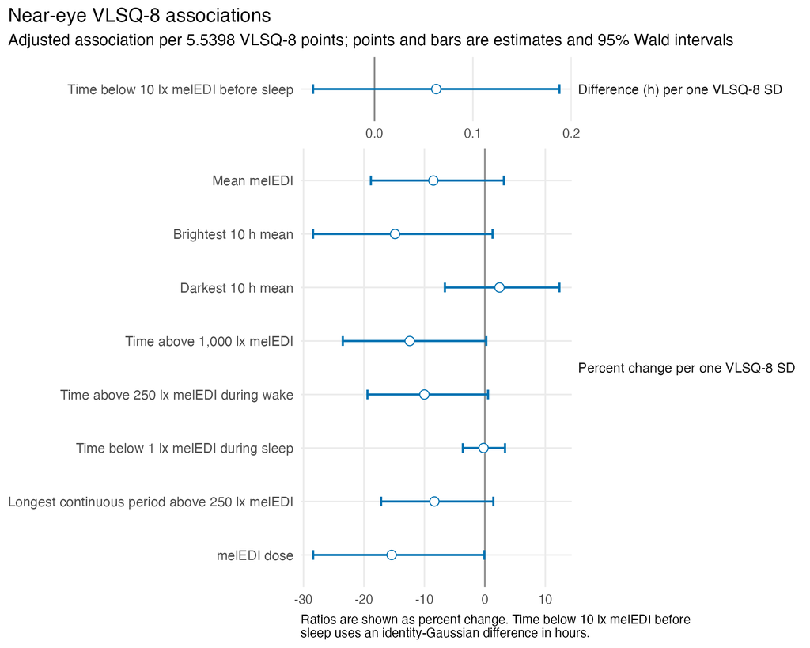

Figure 1: Primary near-eye average associations between VLSQ-8 and the nine personal light-exposure metrics. Points show effects per one participant-level VLSQ-8 SD; horizontal lines are 95% Wald confidence intervals.

Source data for the near-eye figure

# 5 Complementary chest results

Chest results are complementary rather than a second primary screen. No average chest association survived its nine-member family (0 adjusted-positive results), and no chest interaction survived its separate family (0 adjusted-positive results).

Complementary chest average VLSQ-8 associations

Practical estimate, 95% Wald CI, REPORT-008 p-values, and exact fitted sample

| Metric | Effect per 5.540 VLSQ-8 points (95% CI) | Raw p | BH-adjusted p | Participants / participant-days / sites | Diagnostics |
| --- | --- | --- | --- | --- | --- |
| Mean melEDI | 0.935× (0.840 to 1.041) | 0.223 | 0.286 | 154 / 902 / 8 | Pass |
| Brightest 10 h mean | 0.888× (0.761 to 1.037) | 0.136 | 0.245 | 154 / 902 / 8 | Pass |
| Darkest 10 h mean | 1.017× (0.936 to 1.105) | 0.687 | 0.773 | 154 / 902 / 8 | RESIDUAL SPREAD REVIEW |
| Time above 1,000 lx melEDI | 0.873× (0.776 to 0.983) | 0.025 | 0.168 | 154 / 902 / 8 | Pass |
| Time above 250 lx melEDI during wake | 0.920× (0.840 to 1.008) | 0.075 | 0.168 | 154 / 818 / 8 | Pass |
| Time below 10 lx melEDI before sleep | +0.067 h (-0.037 to +0.171) | 0.208 | 0.286 | 153 / 743 / 8 | Pass |
| Time below 1 lx melEDI during sleep | 0.997× (0.970 to 1.026) | 0.857 | 0.857 | 154 / 861 / 8 | ZERO MASS REVIEW |
| Longest continuous period above 250 lx melEDI | 0.925× (0.853 to 1.002) | 0.059 | 0.168 | 154 / 902 / 8 | Pass |
| melEDI dose | 0.869× (0.752 to 1.004) | 0.058 | 0.168 | 154 / 851 / 8 | Pass |

The chest placement is complementary. BH adjustment is separate from the primary near-eye family. Significant adjusted p-values would be bold; none is bold.

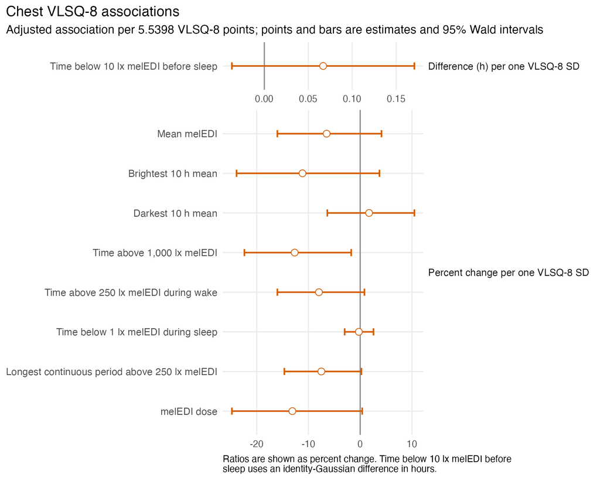

Figure 2: Complementary chest average associations between VLSQ-8 and the nine personal light-exposure metrics. Points show effects per one participant-level VLSQ-8 SD; horizontal lines are 95% Wald confidence intervals.

Source data for the chest figure

# 6 Interaction structure and estimands

## 6.1 Global site-heterogeneity tests

The interaction comparison asks whether the VLSQ-8 slope varies by submitted site after the average slope has been added. It is not the primary average association test.

Separate site-by-VLSQ-8 heterogeneity families

| Placement | Metric | LRT df | Raw p | BH-adjusted p | Status |
| --- | --- | --- | --- | --- | --- |
| Chest | Mean melEDI | 7 | 0.033 | 0.100 | ESTIMABLE |
| Near eye | Mean melEDI | 8 | 0.574 | 0.813 | ESTIMABLE |
| Chest | Brightest 10 h mean | 7 | 0.025 | 0.100 | ESTIMABLE |
| Near eye | Brightest 10 h mean | 8 | 0.284 | 0.813 | ESTIMABLE |
| Chest | Darkest 10 h mean | 7 | 0.523 | 0.609 | ESTIMABLE |
| Near eye | Darkest 10 h mean | 8 | 0.407 | 0.813 | ESTIMABLE |
| Chest | Time above 1,000 lx melEDI | 7 | 0.320 | 0.598 | ESTIMABLE |
| Near eye | Time above 1,000 lx melEDI | 8 | 0.345 | 0.813 | ESTIMABLE |
| Chest | Time above 250 lx melEDI during wake | 7 | 0.836 | 0.836 | ESTIMABLE |
| Near eye | Time above 250 lx melEDI during wake | 8 | 0.852 | 0.852 | ESTIMABLE |
| Chest | Time below 10 lx melEDI before sleep | 7 | 0.025 | 0.100 | ESTIMABLE |
| Near eye | Time below 10 lx melEDI before sleep | 8 | 0.080 | 0.718 | ESTIMABLE |
| Chest | Time below 1 lx melEDI during sleep | 7 | 0.399 | 0.598 | ESTIMABLE |
| Near eye | Time below 1 lx melEDI during sleep | 8 | 0.632 | 0.813 | ESTIMABLE |
| Chest | Longest continuous period above 250 lx melEDI | 7 | 0.541 | 0.609 | ESTIMABLE |
| Near eye | Longest continuous period above 250 lx melEDI | 8 | 0.748 | 0.842 | ESTIMABLE |
| Chest | melEDI dose | 7 | 0.349 | 0.598 | ESTIMABLE |
| Near eye | melEDI dose | 8 | 0.512 | 0.813 | ESTIMABLE |

Each placement has its own complete nine-member BH family. Significant adjusted p-values would be bold; none is bold.

## 6.2 Site-specific slopes

Site-specific slopes are secondary estimates from the interaction models. They are shown with 95% intervals for transparency, not as new site-wise hypothesis families and not as evidence for site differences when the global heterogeneity test is inconclusive.

Site-specific VLSQ-8 slopes

Effect per one VLSQ-8 SD (95% Wald CI)

| Metric | Site | Chest | Near eye |
| --- | --- | --- | --- |
| Mean melEDI | Borås (SE) | 0.749× (0.553 to 1.015) | 0.865× (0.623 to 1.202) |
| Mean melEDI | Delft (NL) | 0.930× (0.647 to 1.337) | 0.883× (0.530 to 1.472) |
| Mean melEDI | Dortmund (DE) | 1.106× (0.853 to 1.433) | 1.088× (0.807 to 1.467) |
| Mean melEDI | Tübingen (DE) | — | 0.906× (0.701 to 1.170) |
| Mean melEDI | Munich (DE) | 1.503× (0.797 to 2.836) | 1.161× (0.589 to 2.289) |
| Mean melEDI | Madrid (ES) | 0.642× (0.486 to 0.850) | 0.681× (0.507 to 0.916) |
| Mean melEDI | Izmir (TR) | 0.912× (0.700 to 1.189) | 0.949× (0.714 to 1.261) |
| Mean melEDI | San José (CR) | 1.001× (0.826 to 1.214) | 0.947× (0.482 to 1.861) |
| Mean melEDI | Kumasi (GH) | 1.323× (0.879 to 1.992) | 1.146× (0.740 to 1.774) |
| Brightest 10 h mean | Borås (SE) | 0.574× (0.371 to 0.888) | 0.682× (0.426 to 1.091) |
| Brightest 10 h mean | Delft (NL) | 0.800× (0.476 to 1.347) | 0.645× (0.310 to 1.339) |
| Brightest 10 h mean | Dortmund (DE) | 1.122× (0.773 to 1.628) | 1.140× (0.744 to 1.749) |
| Brightest 10 h mean | Tübingen (DE) | — | 0.816× (0.565 to 1.178) |
| Brightest 10 h mean | Munich (DE) | 1.803× (0.725 to 4.484) | 1.102× (0.418 to 2.911) |
| Brightest 10 h mean | Madrid (ES) | 0.570× (0.381 to 0.853) | 0.599× (0.392 to 0.915) |
| Brightest 10 h mean | Izmir (TR) | 0.799× (0.546 to 1.169) | 0.852× (0.568 to 1.280) |
| Brightest 10 h mean | San José (CR) | 1.051× (0.797 to 1.386) | 1.516× (0.573 to 4.009) |
| Brightest 10 h mean | Kumasi (GH) | 1.452× (0.806 to 2.618) | 1.415× (0.756 to 2.649) |
| Darkest 10 h mean | Borås (SE) | 1.031× (0.810 to 1.311) | 1.131× (0.879 to 1.455) |
| Darkest 10 h mean | Delft (NL) | 1.070× (0.802 to 1.428) | 1.132× (0.766 to 1.674) |
| Darkest 10 h mean | Dortmund (DE) | 1.058× (0.861 to 1.298) | 1.055× (0.839 to 1.327) |
| Darkest 10 h mean | Tübingen (DE) | — | 1.058× (0.869 to 1.287) |
| Darkest 10 h mean | Munich (DE) | 1.082× (0.654 to 1.790) | 0.964× (0.573 to 1.622) |
| Darkest 10 h mean | Madrid (ES) | 0.862× (0.691 to 1.075) | 0.866× (0.690 to 1.087) |
| Darkest 10 h mean | Izmir (TR) | 1.135× (0.920 to 1.402) | 1.134× (0.912 to 1.411) |
| Darkest 10 h mean | San José (CR) | 0.943× (0.810 to 1.099) | 0.586× (0.350 to 0.983) |
| Darkest 10 h mean | Kumasi (GH) | 1.269× (0.918 to 1.754) | 1.001× (0.717 to 1.399) |
| Time above 1,000 lx melEDI | Borås (SE) | 0.648× (0.464 to 0.906) | 0.646× (0.451 to 0.926) |
| Time above 1,000 lx melEDI | Delft (NL) | 0.983× (0.663 to 1.457) | 0.769× (0.449 to 1.317) |
| Time above 1,000 lx melEDI | Dortmund (DE) | 0.900× (0.680 to 1.193) | 1.017× (0.742 to 1.394) |

[output cut: 51 more lines]

## 6.3 Centred low-to-high predictions

The table compares predictions at half an SD below and half an SD above the observed score mean, averaging the sum-contrast site effect. These are predictions, not additional tests.

Centred VLSQ-8 prediction contrast

| Placement | Metric | Higher score: Score | Lower score: Score | Higher score: Prediction | Lower score: Prediction |
| --- | --- | --- | --- | --- | --- |
| Chest | Mean melEDI | 24.368 | 18.828 | 4.103 (3.565 to 4.641) | 4.394 (3.810 to 4.979) |
| Near eye | Mean melEDI | 24.368 | 18.828 | 5.111 (4.354 to 5.867) | 5.596 (4.760 to 6.432) |
| Chest | Brightest 10 h mean | 24.368 | 18.828 | 76.489 (61.806 to 91.173) | 86.102 (69.861 to 102.342) |
| Near eye | Brightest 10 h mean | 24.368 | 18.828 | 93.318 (73.150 to 113.486) | 109.621 (86.294 to 132.948) |
| Chest | Darkest 10 h mean | 24.368 | 18.828 | 0.115 (0.094 to 0.136) | 0.111 (0.090 to 0.133) |
| Near eye | Darkest 10 h mean | 24.368 | 18.828 | 0.156 (0.127 to 0.185) | 0.150 (0.121 to 0.179) |
| Chest | Time above 1,000 lx melEDI | 24.368 | 18.828 | 1.006 (0.865 to 1.147) | 1.152 (0.997 to 1.307) |
| Near eye | Time above 1,000 lx melEDI | 24.368 | 18.828 | 0.894 (0.750 to 1.039) | 1.021 (0.864 to 1.179) |
| Chest | Time above 250 lx melEDI during wake | 24.368 | 18.828 | 2.488 (2.220 to 2.756) | 2.704 (2.420 to 2.987) |
| Near eye | Time above 250 lx melEDI during wake | 24.368 | 18.828 | 2.491 (2.169 to 2.814) | 2.768 (2.419 to 3.118) |
| Chest | Time below 10 lx melEDI before sleep | 24.368 | 18.828 | 1.996 (1.876 to 2.117) | 1.929 (1.809 to 2.050) |
| Near eye | Time below 10 lx melEDI before sleep | 24.368 | 18.828 | 1.901 (1.758 to 2.043) | 1.838 (1.692 to 1.983) |
| Chest | Time below 1 lx melEDI during sleep | 24.368 | 18.828 | 7.108 (6.880 to 7.336) | 7.126 (6.898 to 7.354) |
| Near eye | Time below 1 lx melEDI during sleep | 24.368 | 18.828 | 6.889 (6.617 to 7.160) | 6.904 (6.627 to 7.180) |
| Chest | Longest continuous period above 250 lx melEDI | 24.368 | 18.828 | 0.539 (0.479 to 0.599) | 0.591 (0.526 to 0.655) |
| Near eye | Longest continuous period above 250 lx melEDI | 24.368 | 18.828 | 0.582 (0.502 to 0.661) | 0.644 (0.557 to 0.730) |
| Chest | melEDI dose | 24.368 | 18.828 | 5407.925 (4460.699 to 6355.150) | 6223.882 (5160.787 to 7286.977) |
| Near eye | melEDI dose | 24.368 | 18.828 | 4368.770 (3499.937 to 5237.602) | 5165.511 (4154.625 to 6176.397) |

Predictions are on each metric’s natural scale and include 95% delta-method intervals with physical lower bounds applied.

# 7 Paired-placement comparison

Near-eye and chest models were fitted separately on exactly matched participant-day keys. The display compares estimates; it does not pool placements, estimate within-day placement differences, or claim equivalence.

Exactly paired near-eye and chest estimates

| Metric | Chest: Effect | Near eye: Effect | Chest: Sample | Near eye: Sample |
| --- | --- | --- | --- | --- |
| Mean melEDI | 0.925× (0.802 to 1.068) | 0.931× (0.812 to 1.066) | 112 / 643 / 8 | 112 / 643 / 8 |
| Brightest 10 h mean | 0.866× (0.705 to 1.065) | 0.878× (0.725 to 1.063) | 112 / 643 / 8 | 112 / 643 / 8 |
| Darkest 10 h mean | 1.042× (0.939 to 1.155) | 1.021× (0.918 to 1.136) | 112 / 643 / 8 | 112 / 643 / 8 |
| Time above 1,000 lx melEDI | 0.872× (0.754 to 1.008) | 0.891× (0.776 to 1.023) | 112 / 643 / 8 | 112 / 643 / 8 |
| Time above 250 lx melEDI during wake | 0.938× (0.843 to 1.043) | 0.932× (0.837 to 1.038) | 112 / 578 / 8 | 112 / 578 / 8 |
| Time below 10 lx melEDI before sleep | +0.114 h (-0.019 to +0.246) | +0.126 h (-0.013 to +0.264) | 110 / 505 / 8 | 110 / 505 / 8 |
| Time below 1 lx melEDI during sleep | 0.991× (0.955 to 1.028) | 0.998× (0.957 to 1.040) | 112 / 608 / 8 | 112 / 608 / 8 |
| Longest continuous period above 250 lx melEDI | 0.935× (0.849 to 1.031) | 0.929× (0.838 to 1.030) | 112 / 643 / 8 | 112 / 643 / 8 |
| melEDI dose | 0.832× (0.691 to 1.001) | 0.872× (0.729 to 1.043) | 112 / 598 / 8 | 112 / 598 / 8 |

Effects are per one VLSQ-8 SD with 95% Wald CIs. Sample cells are participants / participant-days / sites. This comparison carries estimates and intervals only; it is not an extra p-value screen.

The identity-line plot contains only ratio-scale metrics. The pre-sleep metric has an additive hour-difference scale and is therefore kept in the adjacent table rather than mixed into that geometry.

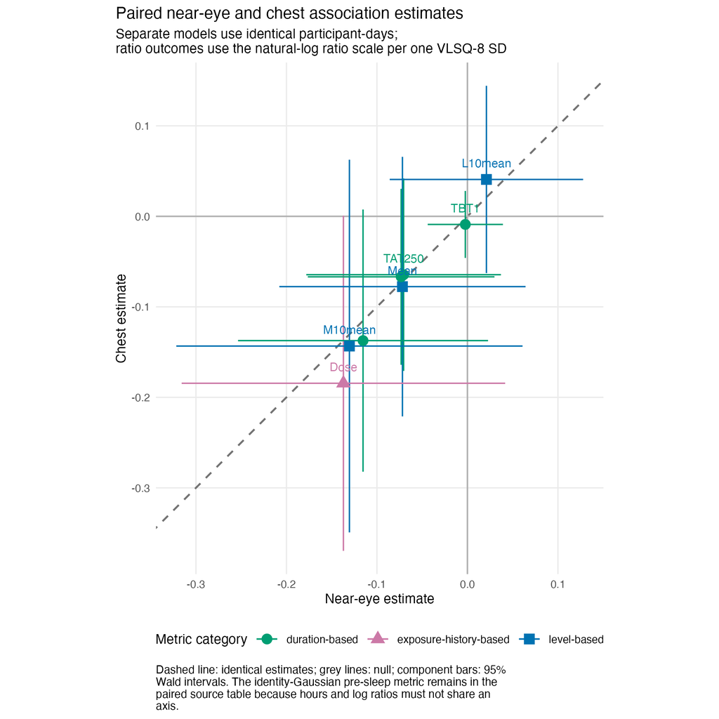

Figure 3: Near-eye and chest VLSQ-8 associations estimated on identical participant-day samples. Ratio-scale metrics only; diagonal line marks equal point estimates, not an equivalence region.

Source data for the paired-placement figure

# 8 Diagnostics and response-family gate

All 36 primary-dataset additive and interaction fits converged, had positive-definite Hessians, were nonsingular, and retained full-rank fixed effects. No primary or complementary effect was declared non-estimable. The diagnostic gate retained all nine approved response specifications; three need explicit limitations rather than a post-result family switch.

Common response-family gate

| Metric | Response / transform | Inferential targets | Major failures | Review targets | Decision |
| --- | --- | --- | --- | --- | --- |
| Mean melEDI | gaussian / log10_offset_0.1 | 4 | 0 | 0 | PASS |
| Brightest 10 h mean | gaussian / log10_offset_0.1 | 4 | 0 | 0 | PASS |
| Darkest 10 h mean | gaussian / log10_offset_0.1 | 4 | 0 | 4 | RETAIN WITH EXPLICIT LIMITATIONS |
| Time above 1,000 lx melEDI | tweedie_log / identity | 4 | 0 | 0 | PASS |
| Time above 250 lx melEDI during wake | tweedie_log / identity | 4 | 0 | 0 | PASS |
| Time below 10 lx melEDI before sleep | gaussian / identity | 4 | 0 | 0 | PASS |
| Time below 1 lx melEDI during sleep | tweedie_log / identity | 4 | 0 | 4 | RETAIN WITH EXPLICIT LIMITATIONS |
| Longest continuous period above 250 lx melEDI | gaussian / log10_offset_0.1 | 4 | 0 | 0 | PASS |
| melEDI dose | gaussian / log10_offset_0.1 | 4 | 0 | 2 | RETAIN WITH EXPLICIT LIMITATIONS |

A review flag triggers explicit qualification; it does not permit data-dependent response-family switching.

Interpreted primary-dataset diagnostics

| Placement | Metric | Maximum gradient | Residual \|fit\| Spearman | Consecutive-day residual r | Observed / expected zeros | Bound check | Diagnostic decision |
| --- | --- | --- | --- | --- | --- | --- | --- |
| Chest | Mean melEDI | 1.6e-05 | -0.168 | -0.033 | — | PASS | PASS |
| Near eye | Mean melEDI | 1e-06 | -0.190 | +0.009 | — | PASS | PASS |
| Chest | Brightest 10 h mean | 2e-06 | -0.213 | -0.034 | — | PASS | PASS |
| Near eye | Brightest 10 h mean | 3e-05 | -0.232 | +0.012 | — | PASS | PASS |
| Chest | Darkest 10 h mean | 1.3e-06 | +0.349 | -0.007 | — | PASS | RESIDUAL SPREAD REVIEW |
| Near eye | Darkest 10 h mean | 1.8e-05 | +0.341 | -0.092 | — | PASS | RESIDUAL SPREAD REVIEW |
| Chest | Time above 1,000 lx melEDI | NA | +0.096 | -0.058 | 85 / 82.9 | PASS | PASS |
| Near eye | Time above 1,000 lx melEDI | NA | +0.110 | -0.121 | 103 / 100 | PASS | PASS |
| Chest | Time above 250 lx melEDI during wake | NA | -0.079 | +0.039 | 20 / 18.8 | PASS | PASS |
| Near eye | Time above 250 lx melEDI during wake | NA | -0.118 | +0.063 | 25 / 21.2 | PASS | PASS |
| Chest | Time below 10 lx melEDI before sleep | 7.1e-06 | -0.061 | -0.152 | — | PASS | PASS |
| Near eye | Time below 10 lx melEDI before sleep | 1.7e-06 | -0.070 | -0.229 | — | PASS | PASS |
| Chest | Time below 1 lx melEDI during sleep | NA | -0.063 | +0.015 | 4 / 5.58e-05 | PASS | ZERO MASS REVIEW |
| Near eye | Time below 1 lx melEDI during sleep | NA | -0.091 | +0.007 | 4 / 7.35e-05 | PASS | ZERO MASS REVIEW |
| Chest | Longest continuous period above 250 lx melEDI | 3.1e-06 | -0.037 | -0.019 | — | PASS | PASS |
| Near eye | Longest continuous period above 250 lx melEDI | 8.9e-05 | -0.126 | -0.004 | — | PASS | PASS |
| Chest | melEDI dose | 1.3e-06 | -0.081 | -0.038 | — | PASS | PASS |
| Near eye | melEDI dose | 9.5e-06 | -0.118 | -0.019 | — | PASS | PASS |

Serial correlations are descriptive pooled checks. Zero expectations are analytical compound-Poisson probabilities from the fitted Tweedie model; no simulation was used.

The main limitations are specific:

- Darkest 10 h mean showed increasing residual spread with fitted values (absolute-residual versus fitted Spearman correlations 0.341 near eye and 0.349 chest). Its direction and intervals should therefore be read with extra caution.
- Time below 1 lx melEDI during sleep contained four observed exact zeros at each placement, whereas the fitted compound-Poisson model assigned an extremely small expected zero count. This is a conspicuous relative discrepancy but only four rows in each large fitted frame. The model is retained under the approved common-family gate, with the zero-mass mismatch stated explicitly.
- The corrected melEDI-dose fits passed the main numerical checks, but the correction is timing-dependent and is therefore interpreted alongside the exact common-sample dataset and observed-dose sensitivities below.

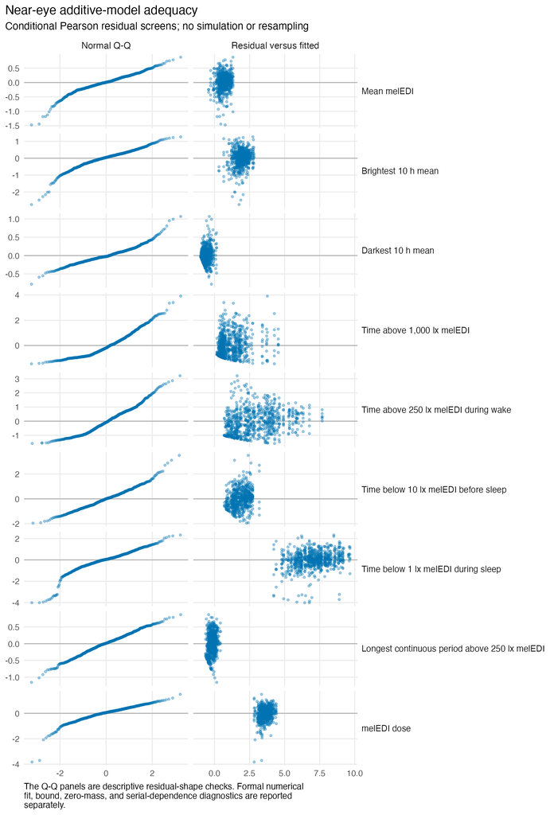

Figure 4: Selected near-eye model-adequacy checks for all nine metrics. Panels retain the model-specific transformed or Pearson-residual scales and are diagnostic rather than effect displays.

Source data for the adequacy figure

## 8.1 Site and participant influence

All 153 planned leave-one-site-out refits succeeded. Some point estimates were direction- or magnitude-sensitive to omitting one site, which reinforces the inconclusive family-level interpretation. No site was removed. The participant screen ranks the five largest residual profiles for each main placement-by-metric fit; it is a transparent review list, not a deletion rule, and no participant was excluded after seeing it.

Leave-one-site-out stability

| Placement | Metric | Refits | Sign reversal | Largest relative \|change\| | Most influential omitted site | Interpretation |
| --- | --- | --- | --- | --- | --- | --- |
| Chest | Mean melEDI | 8 / 8 | FALSE | 0.86 | Madrid (ES) | magnitude-sensitive to one site |
| Near eye | Mean melEDI | 9 / 9 | FALSE | 0.62 | Madrid (ES) | magnitude-sensitive to one site |
| Chest | Brightest 10 h mean | 8 / 8 | FALSE | 0.58 | Madrid (ES) | magnitude-sensitive to one site |
| Near eye | Brightest 10 h mean | 9 / 9 | FALSE | 0.41 | Madrid (ES) | direction stable in leave-one-site-out refits |
| Chest | Darkest 10 h mean | 8 / 8 | TRUE | 1.74 | San José (CR) | direction-sensitive to one site |
| Near eye | Darkest 10 h mean | 9 / 9 | FALSE | 1.30 | Madrid (ES) | magnitude-sensitive to one site |
| Chest | Time above 1,000 lx melEDI | 8 / 8 | FALSE | 0.30 | Borås (SE) | direction stable in leave-one-site-out refits |
| Near eye | Time above 1,000 lx melEDI | 9 / 9 | FALSE | 0.35 | Borås (SE) | direction stable in leave-one-site-out refits |
| Chest | Time above 250 lx melEDI during wake | 8 / 8 | FALSE | 0.23 | San José (CR) | direction stable in leave-one-site-out refits |
| Near eye | Time above 250 lx melEDI during wake | 9 / 9 | FALSE | 0.24 | Tübingen (DE) | direction stable in leave-one-site-out refits |
| Chest | Time below 10 lx melEDI before sleep | 8 / 8 | FALSE | 1.11 | Dortmund (DE) | magnitude-sensitive to one site |
| Near eye | Time below 10 lx melEDI before sleep | 9 / 9 | FALSE | 1.02 | Tübingen (DE) | magnitude-sensitive to one site |
| Chest | Time below 1 lx melEDI during sleep | 8 / 8 | TRUE | 3.52 | Madrid (ES) | direction-sensitive to one site |
| Near eye | Time below 1 lx melEDI during sleep | 9 / 9 | TRUE | 3.98 | Izmir (TR) | direction-sensitive to one site |
| Chest | Longest continuous period above 250 lx melEDI | 8 / 8 | FALSE | 0.28 | Borås (SE) | direction stable in leave-one-site-out refits |
| Near eye | Longest continuous period above 250 lx melEDI | 9 / 9 | FALSE | 0.28 | Borås (SE) | direction stable in leave-one-site-out refits |
| Chest | melEDI dose | 8 / 8 | FALSE | 0.44 | Borås (SE) | direction stable in leave-one-site-out refits |
| Near eye | melEDI dose | 9 / 9 | FALSE | 0.34 | Borås (SE) | direction stable in leave-one-site-out refits |

Relative changes can be large when the full-sample estimate is close to zero. They do not by themselves identify an erroneous site.

Download the participant influence screen.

# 9 Gap-timing-unaware dataset sensitivity

The strongest dataset comparison uses identical row keys across datasets, placement, and metric. All 18 exact-common-sample estimates were classified as stable within model uncertainty. The scenario-specific all-available families had no BH-adjusted conclusion change. Within those all-available fits, near-eye wake time above 250 lx melEDI and corrected melEDI dose were precision-sensitive because a 95% interval’s zero-exclusion changed; all chest comparisons were stable within model uncertainty.

Exact-common-sample dataset sensitivity

| Placement | Metric | Primary effect (95% CI) | Gap-timing-unaware effect (95% CI) | Sample | Exact row keys | Stability |
| --- | --- | --- | --- | --- | --- | --- |
| Chest | Mean melEDI | 0.934× (0.839 to 1.041) | 0.935× (0.839 to 1.042) | 154 / 894 / 8 | TRUE | stable within model uncertainty |
| Near eye | Mean melEDI | 0.914× (0.810 to 1.030) | 0.912× (0.809 to 1.030) | 141 / 809 / 9 | TRUE | stable within model uncertainty |
| Chest | Brightest 10 h mean | 0.888× (0.760 to 1.038) | 0.887× (0.762 to 1.034) | 154 / 894 / 8 | TRUE | stable within model uncertainty |
| Near eye | Brightest 10 h mean | 0.851× (0.715 to 1.014) | 0.852× (0.721 to 1.007) | 141 / 809 / 9 | TRUE | stable within model uncertainty |
| Chest | Darkest 10 h mean | 1.014× (0.933 to 1.102) | 1.004× (0.926 to 1.088) | 154 / 894 / 8 | TRUE | stable within model uncertainty |
| Near eye | Darkest 10 h mean | 1.021× (0.930 to 1.121) | 1.010× (0.922 to 1.107) | 141 / 809 / 9 | TRUE | stable within model uncertainty |
| Chest | Time above 1,000 lx melEDI | 0.873× (0.777 to 0.981) | 0.872× (0.775 to 0.982) | 154 / 894 / 8 | TRUE | stable within model uncertainty |
| Near eye | Time above 1,000 lx melEDI | 0.875× (0.765 to 1.001) | 0.873× (0.762 to 1.001) | 141 / 809 / 9 | TRUE | stable within model uncertainty |
| Chest | Time above 250 lx melEDI during wake | 0.919× (0.839 to 1.006) | 0.919× (0.839 to 1.007) | 153 / 800 / 8 | TRUE | stable within model uncertainty |
| Near eye | Time above 250 lx melEDI during wake | 0.899× (0.804 to 1.005) | 0.897× (0.801 to 1.003) | 140 / 719 / 9 | TRUE | stable within model uncertainty |
| Chest | Time below 10 lx melEDI before sleep | +0.067 h (-0.037 to +0.171) | +0.068 h (-0.036 to +0.172) | 153 / 740 / 8 | TRUE | stable within model uncertainty |
| Near eye | Time below 10 lx melEDI before sleep | +0.061 h (-0.064 to +0.187) | +0.063 h (-0.063 to +0.188) | 139 / 653 / 9 | TRUE | stable within model uncertainty |
| Chest | Time below 1 lx melEDI during sleep | 0.998× (0.970 to 1.026) | 0.998× (0.970 to 1.027) | 154 / 853 / 8 | TRUE | stable within model uncertainty |
| Near eye | Time below 1 lx melEDI during sleep | 0.998× (0.963 to 1.033) | 0.998× (0.964 to 1.034) | 141 / 771 / 9 | TRUE | stable within model uncertainty |
| Chest | Longest continuous period above 250 lx melEDI | 0.924× (0.852 to 1.002) | 0.923× (0.849 to 1.003) | 154 / 894 / 8 | TRUE | stable within model uncertainty |
| Near eye | Longest continuous period above 250 lx melEDI | 0.918× (0.829 to 1.016) | 0.918× (0.828 to 1.019) | 141 / 809 / 9 | TRUE | stable within model uncertainty |
| Chest | melEDI dose | 0.867× (0.751 to 1.002) | 0.869× (0.752 to 1.004) | 154 / 847 / 8 | TRUE | stable within model uncertainty |
| Near eye | melEDI dose | 0.843× (0.714 to 0.996) | 0.837× (0.708 to 0.990) | 141 / 757 / 9 | TRUE | stable within model uncertainty |

Effects are per one VLSQ-8 SD with 95% Wald CIs. These comparisons carry no additional p-value screen.

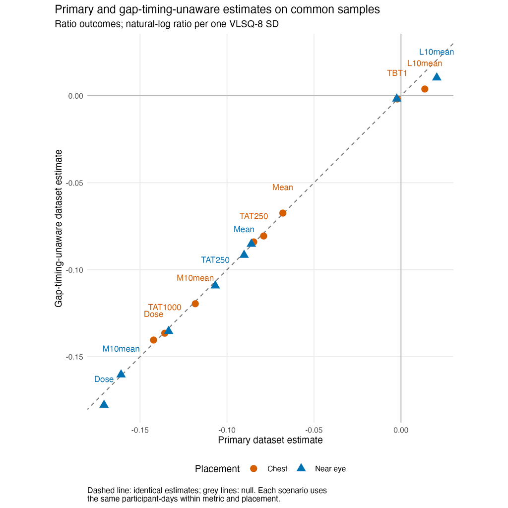

Figure 5: Primary and gap-timing-unaware VLSQ-8 associations on exactly matched participant-day samples, shown separately for near-eye and chest placements.

Source data for the common-sample dataset figure

Scenario-specific all-available stability classifications

| Placement | Stability | Metrics |
| --- | --- | --- |
| Chest | stable within model uncertainty | 9 |
| Near eye | precision-sensitive | 2 |
| Near eye | stable within model uncertainty | 7 |

These fits can differ in both metric values and available rows; the exact-common-sample table above isolates value-definition changes.

# 10 Other prespecified sensitivities

## 10.1 Photoperiod adjustment and participant summaries

Linear centred photoperiod was added only as a sensitivity covariate, with site retained and no photoperiod interaction. Participant-summary models give each participant one outcome value and use the corresponding fixed-effects model. All 36 additive sensitivity fits converged and retained full-rank fixed effects. Their estimates were broadly compatible with the participant-day results; they are not new multiplicity screens.

Photoperiod-adjusted and participant-summary estimates

| Sensitivity | Placement | Metric | Effect per VLSQ-8 SD (95% CI) | Sample | Converged / full rank |
| --- | --- | --- | --- | --- | --- |
| Participant summary | Chest | Mean melEDI | 0.936× (0.839 to 1.045) | 154 / 902 / 8 | TRUE / TRUE |
| Participant summary | Near eye | Mean melEDI | 0.929× (0.820 to 1.054) | 141 / 816 / 9 | TRUE / TRUE |
| Photoperiod-adjusted | Chest | Mean melEDI | 0.928× (0.838 to 1.026) | 154 / 902 / 8 | TRUE / TRUE |
| Photoperiod-adjusted | Near eye | Mean melEDI | 0.931× (0.835 to 1.039) | 141 / 816 / 9 | TRUE / TRUE |
| Participant summary | Chest | Brightest 10 h mean | 0.891× (0.771 to 1.030) | 154 / 902 / 8 | TRUE / TRUE |
| Participant summary | Near eye | Brightest 10 h mean | 0.900× (0.757 to 1.071) | 141 / 816 / 9 | TRUE / TRUE |
| Photoperiod-adjusted | Chest | Brightest 10 h mean | 0.879× (0.759 to 1.019) | 154 / 902 / 8 | TRUE / TRUE |
| Photoperiod-adjusted | Near eye | Brightest 10 h mean | 0.871× (0.742 to 1.023) | 141 / 816 / 9 | TRUE / TRUE |
| Participant summary | Chest | Darkest 10 h mean | 1.026× (0.925 to 1.138) | 154 / 902 / 8 | TRUE / TRUE |
| Participant summary | Near eye | Darkest 10 h mean | 1.004× (0.902 to 1.119) | 141 / 816 / 9 | TRUE / TRUE |
| Photoperiod-adjusted | Chest | Darkest 10 h mean | 1.013× (0.934 to 1.099) | 154 / 902 / 8 | TRUE / TRUE |
| Photoperiod-adjusted | Near eye | Darkest 10 h mean | 1.034× (0.945 to 1.131) | 141 / 816 / 9 | TRUE / TRUE |
| Participant summary | Chest | Time above 1,000 lx melEDI | 0.910× (0.811 to 1.020) | 154 / 902 / 8 | TRUE / TRUE |
| Participant summary | Near eye | Time above 1,000 lx melEDI | 0.890× (0.776 to 1.021) | 141 / 816 / 9 | TRUE / TRUE |
| Photoperiod-adjusted | Chest | Time above 1,000 lx melEDI | 0.865× (0.777 to 0.964) | 154 / 902 / 8 | TRUE / TRUE |
| Photoperiod-adjusted | Near eye | Time above 1,000 lx melEDI | 0.892× (0.790 to 1.007) | 141 / 816 / 9 | TRUE / TRUE |
| Participant summary | Chest | Time above 250 lx melEDI during wake | 0.940× (0.862 to 1.024) | 154 / 818 / 8 | TRUE / TRUE |
| Participant summary | Near eye | Time above 250 lx melEDI during wake | 0.912× (0.824 to 1.010) | 141 / 737 / 9 | TRUE / TRUE |
| Photoperiod-adjusted | Chest | Time above 250 lx melEDI during wake | 0.915× (0.840 to 0.997) | 154 / 818 / 8 | TRUE / TRUE |
| Photoperiod-adjusted | Near eye | Time above 250 lx melEDI during wake | 0.913× (0.824 to 1.013) | 141 / 737 / 9 | TRUE / TRUE |
| Participant summary | Chest | Time below 10 lx melEDI before sleep | +0.054 h (-0.055 to +0.162) | 153 / 743 / 8 | TRUE / TRUE |
| Participant summary | Near eye | Time below 10 lx melEDI before sleep | +0.043 h (-0.088 to +0.174) | 139 / 655 / 9 | TRUE / TRUE |
| Photoperiod-adjusted | Chest | Time below 10 lx melEDI before sleep | +0.071 h (-0.031 to +0.172) | 153 / 743 / 8 | TRUE / TRUE |
| Photoperiod-adjusted | Near eye | Time below 10 lx melEDI before sleep | +0.047 h (-0.072 to +0.165) | 139 / 655 / 9 | TRUE / TRUE |
| Participant summary | Chest | Time below 1 lx melEDI during sleep | 1.001× (0.974 to 1.028) | 154 / 861 / 8 | TRUE / TRUE |
| Participant summary | Near eye | Time below 1 lx melEDI during sleep | 1.000× (0.967 to 1.035) | 141 / 778 / 9 | TRUE / TRUE |
| Photoperiod-adjusted | Chest | Time below 1 lx melEDI during sleep | 0.998× (0.971 to 1.026) | 154 / 861 / 8 | TRUE / TRUE |
| Photoperiod-adjusted | Near eye | Time below 1 lx melEDI during sleep | 0.996× (0.962 to 1.032) | 141 / 778 / 9 | TRUE / TRUE |
| Participant summary | Chest | Longest continuous period above 250 lx melEDI | 0.929× (0.854 to 1.011) | 154 / 902 / 8 | TRUE / TRUE |
| Participant summary | Near eye | Longest continuous period above 250 lx melEDI | 0.936× (0.846 to 1.035) | 141 / 816 / 9 | TRUE / TRUE |
| Photoperiod-adjusted | Chest | Longest continuous period above 250 lx melEDI | 0.920× (0.852 to 0.993) | 154 / 902 / 8 | TRUE / TRUE |
| Photoperiod-adjusted | Near eye | Longest continuous period above 250 lx melEDI | 0.928× (0.844 to 1.021) | 141 / 816 / 9 | TRUE / TRUE |
| Participant summary | Chest | melEDI dose | 0.864× (0.753 to 0.992) | 154 / 851 / 8 | TRUE / TRUE |
| Participant summary | Near eye | melEDI dose | 0.886× (0.755 to 1.041) | 141 / 761 / 9 | TRUE / TRUE |
| Photoperiod-adjusted | Chest | melEDI dose | 0.856× (0.750 to 0.976) | 154 / 851 / 8 | TRUE / TRUE |
| Photoperiod-adjusted | Near eye | melEDI dose | 0.868× (0.747 to 1.009) | 141 / 761 / 9 | TRUE / TRUE |

Effects have 95% Wald CIs. Sample cells are participants / contributing participant-days / sites. TRUE / TRUE means convergence and full fixed-effect rank.

## 10.2 Exactly identified longest period and observed dose

The primary longest-period metric is an observed lower bound. Requiring exact identification reduced the available sample and did not yield a precise association: near eye 0.958× (95% CI 0.856–1.072) and chest 0.939× (95% CI 0.855–1.032). On the exactly paired sample, estimates were 0.943× near eye and 0.952× chest, with both intervals crossing one.

The observed-dose comparison holds the corrected-dose fitted sample fixed and replaces the value with uncorrected observed dose. It is descriptive. The all-available near-eye estimate was 0.842× (95% CI 0.713–0.995), but the paired near-eye interval crossed one; the chest all-available interval also reached one. These sensitivities do not override the primary BH family.

Metric-definition sensitivities

| Sensitivity | Placement | Sample basis | Effect per VLSQ-8 SD (95% CI) | Sample | Status |
| --- | --- | --- | --- | --- | --- |
| Exactly identified longest period | Chest | All available | 0.939× (0.855 to 1.032) | 150 / 564 / 8 | PASS |
| Exactly identified longest period | Near eye | All available | 0.958× (0.856 to 1.072) | 132 / 500 / 9 | PASS |
| Exactly identified longest period | Chest | Paired placement | 0.952× (0.847 to 1.070) | 105 / 374 / 8 | PASS |
| Exactly identified longest period | Near eye | Paired placement | 0.943× (0.837 to 1.063) | 105 / 374 / 8 | PASS |
| Observed dose on corrected-dose sample | Chest | All available | 0.868× (0.752 to 1.003) | 154 / 851 / 8 | PASS |
| Observed dose on corrected-dose sample | Near eye | All available | 0.842× (0.713 to 0.995) | 141 / 761 / 9 | PASS |
| Observed dose on corrected-dose sample | Chest | Paired placement | 0.831× (0.690 to 0.999) | 112 / 598 / 8 | PASS |
| Observed dose on corrected-dose sample | Near eye | Paired placement | 0.871× (0.729 to 1.041) | 112 / 598 / 8 | PASS |

Estimates have 95% Wald CIs and do not carry an additional p-value family.

## 10.3 Deferred upstream-dependent scenarios

Approved Rule B/Rule C daily-denominator variants and the all-zero-inclusive scenario are not H08-ready direct inputs. They remain deferred rather than being approximated within H08. Stage 2 does not require an upstream change request because the available, hash-verified sensitivity battery addresses the current result gate. If the author makes those scenarios mandatory before Stage 3, H08 will write `audit/handoffs/H08_shared_change_request.md` and stop for the upstream producer.

# 11 Multiplicity audit

All eight inferential families contain exactly nine observed raw and adjusted p-values. Independent BH recalculation matched the stored results. No family had an adjusted p-value below 0.05. Paired/common-sample and other sensitivity estimates carry 95% intervals but no additional p-value screen.

Eight complete nine-member H08 families

| Family | Role | Observed / planned | Method | Raw p < 0.05 | Adjusted p < 0.05 | Complete family | Independent check |
| --- | --- | --- | --- | --- | --- | --- | --- |
| H08-C1-main-chest-average | Complementary family | 9 / 9 | BH | 1 | 0 | TRUE | TRUE |
| H08-C2-main-chest-heterogeneity | Complementary family | 9 / 9 | BH | 3 | 0 | TRUE | TRUE |
| H08-F1-main-near-eye-average | Primary decision family | 9 / 9 | BH | 0 | 0 | TRUE | TRUE |
| H08-F2-main-near-eye-heterogeneity | Registered secondary family | 9 / 9 | BH | 0 | 0 | TRUE | TRUE |
| H08-G1-gap-near-eye-average | Sensitivity family | 9 / 9 | BH | 1 | 0 | TRUE | TRUE |
| H08-G2-gap-near-eye-heterogeneity | Sensitivity family | 9 / 9 | BH | 0 | 0 | TRUE | TRUE |
| H08-GC1-gap-chest-average | Complementary sensitivity family | 9 / 9 | BH | 1 | 0 | TRUE | TRUE |
| H08-GC2-gap-chest-heterogeneity | Complementary sensitivity family | 9 / 9 | BH | 2 | 0 | TRUE | TRUE |

REPORT-008 uses a leading zero and three decimals, with values below 0.001 shown as <0.001. Bold is reserved for the adjusted decision; none qualifies here.

# 12 V0 reconstruction and reconciliation

V0 is reproducible from the archived RData files and rendered outputs. It used chest as the main placement, near eye as a robustness repeat, default treatment coding, `(1 | Id)`, and a joint score-plus-site-interaction block as its association test. It then called `p.adjust()` on one scalar at a time with `n = 9`. That scalar operation reproduces the displayed strings but is not a nine-member FDR adjustment. A consistent vector BH calculation is retained in the audit artifact for comparison.

Exact V0 reconstruction

| Placement | Metric | V0 sample | V0 joint raw p | V0 scalar display | Scalar display supported | Consistent vector BH p |
| --- | --- | --- | --- | --- | --- | --- |
| Chest | Mean melEDI | 154 / 897 / 8 | 0.049 | 0.4 | FALSE | 0.220 |
| Near eye | Mean melEDI | 141 / 811 / 9 | 0.457 | >0.9 | FALSE | 0.605 |
| Chest | Brightest 10 h mean | 154 / 897 / 8 | 0.078 | 0.7 | FALSE | 0.234 |
| Near eye | Brightest 10 h mean | 141 / 811 / 9 | 0.223 | >0.9 | FALSE | 0.605 |
| Chest | Darkest 10 h mean | 154 / 897 / 8 | 0.581 | >0.9 | FALSE | 0.581 |
| Near eye | Darkest 10 h mean | 141 / 811 / 9 | 0.323 | >0.9 | FALSE | 0.605 |
| Chest | Time above 1,000 lx melEDI | 154 / 897 / 8 | 0.107 | >0.9 | FALSE | 0.241 |
| Near eye | Time above 1,000 lx melEDI | 141 / 811 / 9 | 0.187 | >0.9 | FALSE | 0.605 |
| Chest | Time above 250 lx melEDI during wake | 153 / 839 / 8 | 0.437 | >0.9 | FALSE | 0.562 |
| Near eye | Time above 250 lx melEDI during wake | 140 / 755 / 9 | 0.471 | >0.9 | FALSE | 0.605 |
| Chest | Time below 10 lx melEDI before sleep | 154 / 867 / 8 | 0.034 | 0.3 | FALSE | 0.220 |
| Near eye | Time below 10 lx melEDI before sleep | 141 / 780 / 9 | 0.133 | >0.9 | FALSE | 0.605 |
| Chest | Time below 1 lx melEDI during sleep | 154 / 878 / 8 | 0.572 | >0.9 | FALSE | 0.581 |
| Near eye | Time below 1 lx melEDI during sleep | 141 / 790 / 9 | 0.672 | >0.9 | FALSE | 0.672 |
| Chest | Longest continuous period above 250 lx melEDI | 154 / 897 / 8 | 0.312 | >0.9 | FALSE | 0.562 |
| Near eye | Longest continuous period above 250 lx melEDI | 141 / 811 / 9 | 0.625 | >0.9 | FALSE | 0.672 |
| Chest | melEDI dose | 154 / 897 / 8 | 0.432 | >0.9 | FALSE | 0.562 |
| Near eye | melEDI dose | 141 / 811 / 9 | 0.464 | >0.9 | FALSE | 0.605 |

Near-eye V0 displayed >0.9 for every metric. Chest displayed 0.4, 0.7, then >0.9 except 0.3 for pre-sleep; the archived render strings and scalar calculation agree.

V0-to-audited result comparison

| Placement | Metric | V0 joint raw p | Audited average raw p | Audited average BH p | Audited effect (95% CI) | Participant-day change | Adjusted conclusion changed |
| --- | --- | --- | --- | --- | --- | --- | --- |
| Chest | Mean melEDI | 0.049 | 0.223 | 0.286 | 0.935× (0.840 to 1.041) | 5 | FALSE |
| Near eye | Mean melEDI | 0.457 | 0.147 | 0.221 | 0.915× (0.811 to 1.031) | 5 | FALSE |
| Chest | Brightest 10 h mean | 0.078 | 0.136 | 0.245 | 0.888× (0.761 to 1.037) | 5 | FALSE |
| Near eye | Brightest 10 h mean | 0.223 | 0.071 | 0.160 | 0.851× (0.716 to 1.013) | 5 | FALSE |
| Chest | Darkest 10 h mean | 0.581 | 0.687 | 0.773 | 1.017× (0.936 to 1.105) | 5 | FALSE |
| Near eye | Darkest 10 h mean | 0.323 | 0.612 | 0.689 | 1.024× (0.934 to 1.123) | 5 | FALSE |
| Chest | Time above 1,000 lx melEDI | 0.107 | 0.025 | 0.168 | 0.873× (0.776 to 0.983) | 5 | FALSE |
| Near eye | Time above 1,000 lx melEDI | 0.187 | 0.056 | 0.160 | 0.876× (0.765 to 1.002) | 5 | FALSE |
| Chest | Time above 250 lx melEDI during wake | 0.437 | 0.075 | 0.168 | 0.920× (0.840 to 1.008) | -21 | FALSE |
| Near eye | Time above 250 lx melEDI during wake | 0.471 | 0.063 | 0.160 | 0.900× (0.806 to 1.005) | -18 | FALSE |
| Chest | Time below 10 lx melEDI before sleep | 0.034 | 0.208 | 0.286 | +0.067 h (-0.037 to +0.171) | -124 | FALSE |
| Near eye | Time below 10 lx melEDI before sleep | 0.133 | 0.328 | 0.422 | +0.063 h (-0.062 to +0.188) | -125 | FALSE |
| Chest | Time below 1 lx melEDI during sleep | 0.572 | 0.857 | 0.857 | 0.997× (0.970 to 1.026) | -17 | FALSE |
| Near eye | Time below 1 lx melEDI during sleep | 0.672 | 0.903 | 0.903 | 0.998× (0.964 to 1.033) | -12 | FALSE |
| Chest | Longest continuous period above 250 lx melEDI | 0.312 | 0.059 | 0.168 | 0.925× (0.853 to 1.002) | 5 | FALSE |
| Near eye | Longest continuous period above 250 lx melEDI | 0.625 | 0.093 | 0.167 | 0.917× (0.828 to 1.014) | 5 | FALSE |
| Chest | melEDI dose | 0.432 | 0.058 | 0.168 | 0.869× (0.752 to 1.004) | -46 | FALSE |
| Near eye | melEDI dose | 0.464 | 0.051 | 0.160 | 0.846× (0.716 to 0.999) | -50 | FALSE |

The tests are not numerically interchangeable: V0 tests the joint score-plus-interaction block, whereas the audited average test adds one centred score slope after site. No audited BH-adjusted conclusion is positive.

The audited implementation therefore does not convert a V0 positive result into a negative one. Rather, it replaces a nonstandard display adjustment and a differently defined joint test with the approved average-slope and heterogeneity families. The defensible Stage 2 conclusion is that the observed data do not provide multiplicity-adjusted evidence of an association between VLSQ-8 score and any of the nine near-eye metrics; chest and the sensitivity battery do not materially strengthen that evidence. Several estimates lean toward less bright-light exposure at higher scores, but their family-adjusted evidence and site stability are inconclusive. These are associations, not physiological responses or health effects.

# 13 Reproducibility and artifact map

The Stage 2 runner fitted all approved models in R 4.6.1, wrote frozen model frames and bundles, and exported tables, diagnostics, figures, source data, and manifests. It used maintained `reformulas` formula helpers. The later METRIC-011 script performed only the bounded L10 maintenance described above and preserved all other model objects. Neither run used bootstrap, simulation, or other resampling, so the pilot-runtime gate was not triggered.

Recorded execution environment

| component | version_or_status |
| --- | --- |
| R | 4.6.1 |
| Quarto | 1.9.37 |
| dplyr | 1.2.1 |
| tidyr | 1.3.2 |
| purrr | 1.2.2 |
| tibble | 3.3.1 |
| readr | 2.2.0 |
| digest | 0.6.39 |
| openssl | 2.4.2 |
| lme4 | 2.0.1 |
| reformulas | 0.4.4 |
| glmmTMB | 1.1.14 |
| performance | 0.17.1 |
| ggplot2 | 4.0.3 |
| scales | 1.4.0 |
| rvest | 1.0.5 |
| gt | 1.3.0 |
| resampling | None; analytical Tweedie zero-mass check used, so no bootstrap/simulation pilot was required |

Consequential package versions, commands, and input files are recorded in the H08 manifest artifacts.

Primary entry points and frozen outputs:

- Stage 2 runner
- Bounded METRIC-011 reseal
- H08 contract
- H08 modelling helpers
- Focused Stage 2 test
- Focused METRIC-011 test
- Master result table
- Complete diagnostic table
- Model-frame rows
- Stage 2 artifact manifest
- Figure manifest and alt text

# 14 Stage 2 package status

**ImportantAccepted result package**

The author accepted the following as one Stage 2 result package:

1. Accept the eight complete nine-member BH families and the conclusion that none has an adjusted p-value below 0.05.
2. Accept the primary near-eye and complementary chest practical estimates, 95% Wald confidence intervals, exact fitted samples, and separate site-heterogeneity interpretation.
3. Accept the retained response families with explicit limitations for Darkest 10 h mean residual spread, sleep-below-1-lx zero mass, and the timing-dependent corrected dose.
4. Accept the leave-one-site-out interpretation: some estimates are site-sensitive, no site is removed, and the overall result remains inconclusive.
5. Accept the exact paired-placement display without pooling or equivalence claims and without an additional p-value screen.
6. Accept the gap-timing-unaware, photoperiod, participant-summary, exactly-identified-longest-period, and observed-dose sensitivity interpretations.
7. Accept the V0 reconstruction and the explanation that V0 and the audited model test different null hypotheses and use different multiplicity procedures.
8. Accept the plain-language claim boundary: no multiplicity-adjusted evidence for an H08 association, with uncertain directional patterns and no causal, physiological, or health-effect claim.

Stage 3 and Stage 4 were subsequently completed and accepted. The Stage 3 notebook includes the REPORT-012 **Results in brief** callout directly after the hypothesis and analytical question. METRIC-011 did not alter that callout or any of the multiplicity, uncertainty, chest, or sensitivity qualifications.